# Análise de Marketing Digital

Tatiane

# 🔍 **Análise de Marketing Digital**

## 📁 Leitura da Base

```r
setwd("/home/tatiane/data-projects/02_data_analysis/etl_marketing_digital/raw/data/")
df <- fread("digital_marketing_campaign_dataset.csv", header = TRUE, dec = ".")
```

## 📊 1. Análise Exploratória

### **Taxa geral de conversão**

```r
mean(df$Conversion)
```

```
## [1] 0.8765
```

**Comentário:** Taxa geral de conversão dá uma visão inicial do desempenho geral das campanhas.

### **Distribuição das variáveis principais**

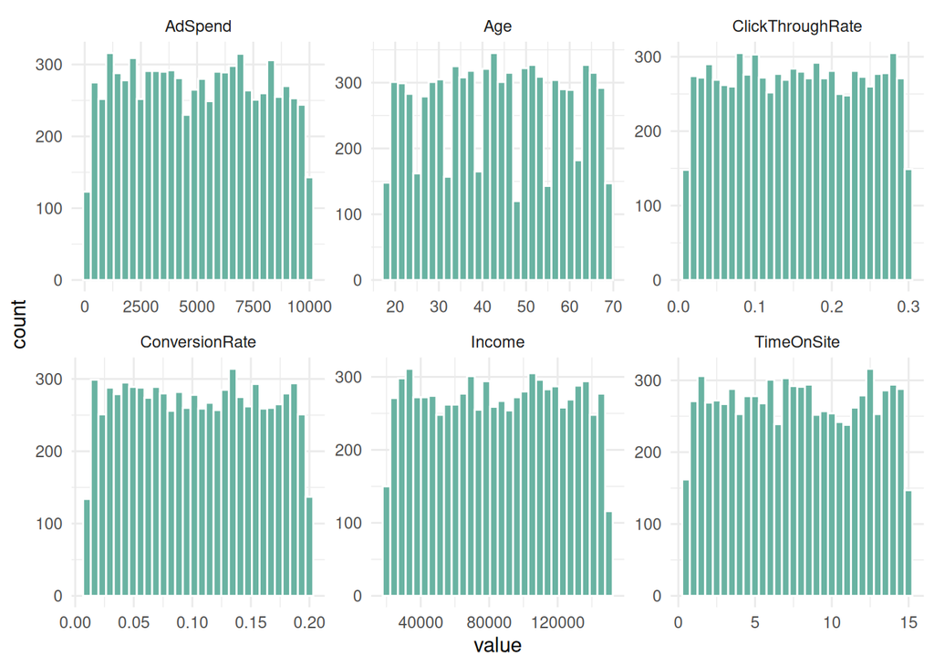

```r
df %>%
  select(Age, Income, AdSpend, ClickThroughRate, ConversionRate, TimeOnSite) %>%
  gather(variable, value) %>%
  ggplot(aes(value)) +
  geom_histogram(fill = "#69b3a2", color = "white") +
  facet_wrap(~variable, scales = "free") +
  theme_minimal()
```

**Comentário:** A distribuição mostra como cada variável se comporta e ajuda a identificar assimetrias e padrões gerais.

## 🔗 Matriz de Correlação

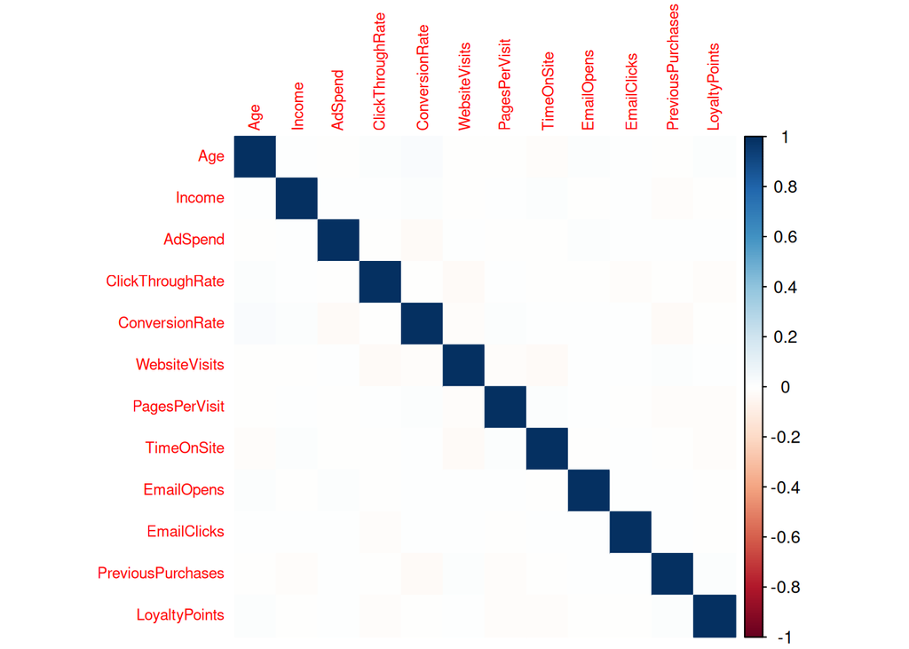

```r
num_vars <- df %>%
  select(Age, Income, AdSpend, ClickThroughRate, ConversionRate,
         WebsiteVisits, PagesPerVisit, TimeOnSite,
         EmailOpens, EmailClicks, PreviousPurchases, LoyaltyPoints)

corr_matrix <- cor(num_vars, use = "complete.obs")
corrplot(corr_matrix, method = "color", tl.cex = 0.7)
```

## 🎯 Correlação das Variáveis com Conversion

```r
correlations_to_target <- sapply(num_vars, function(x)
  cor(x, df$Conversion, method = "pearson", use = "complete.obs")
)

sort(correlations_to_target, decreasing = TRUE)
```

```
##        TimeOnSite       EmailClicks        EmailOpens           AdSpend
##       0.129608827       0.129520541       0.124883957       0.124672066
##  ClickThroughRate PreviousPurchases     PagesPerVisit     LoyaltyPoints
##       0.120012284       0.111781219       0.102840269       0.095004120
##    ConversionRate     WebsiteVisits            Income               Age
##       0.093184779       0.079339201       0.013973537       0.001606051
```

**Comentário:** As correlações ajudam a identificar fatores com maior impacto direto na conversão. - O engajamento pós-clique (TimeOnSite, PagesPerVisit, EmailClicks) parece mais relevante do que características demográficas. - Há um padrão indicando que interações diretas do usuário (cliques, tempo gasto, aberturas) são melhores indicadores de conversão do que características permanentes. - Mesmo as variáveis mais correlacionadas não ultrapassam 0.13, reforçando que a conversão depende da combinação de múltiplos fatores e não de um único driver.

## 📈 Taxa de Conversão por Canal

```r
df %>%
  group_by(CampaignChannel) %>%
  summarise(ConversionRate = mean(Conversion),
            Count = n()) %>%
  arrange(desc(ConversionRate))
```

```
## # A tibble: 5 × 3
##   CampaignChannel ConversionRate Count
##   <chr>                    <dbl> <int>
## 1 Referral                 0.883  1719
## 2 PPC                      0.883  1655
## 3 SEO                      0.877  1550
## 4 Email                    0.870  1557
## 5 Social Media             0.868  1519
```

**Comentário:** Canais com maior taxa de conversão indicam onde o investimento tende a ser mais eficiente.

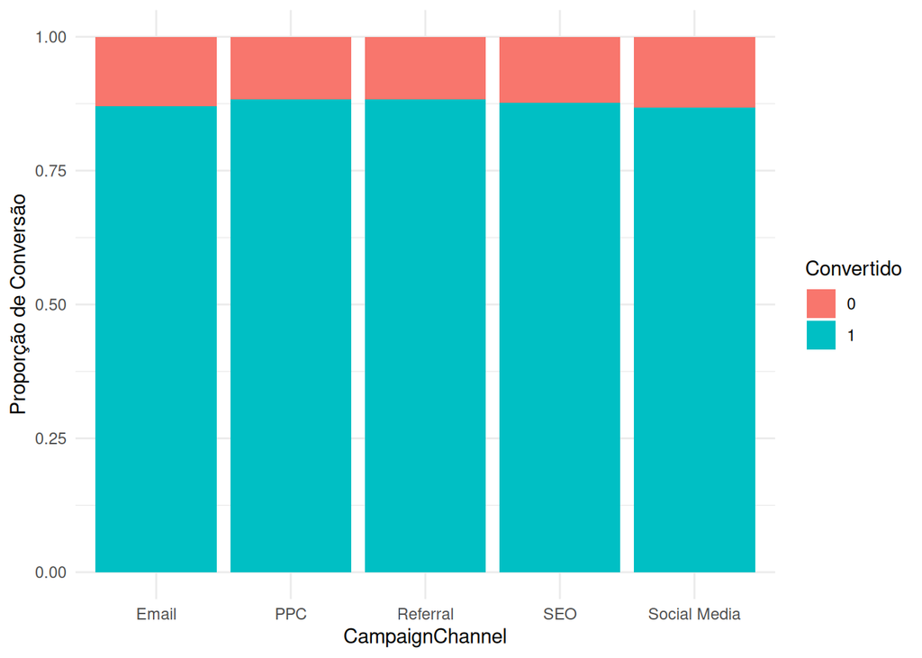

```r
ggplot(df, aes(x = CampaignChannel, fill = factor(Conversion))) +
  geom_bar(position = "fill") +
  labs(y = "Proporção de Conversão", fill = "Convertido") +
  theme_minimal()
```

**Comentário:** O gráfico mostra a proporção de conversão em cada canal, facilitando comparações rápidas.

## 🧪 Teste Qui-Quadrado

```r
chisq.test(table(df$CampaignType, df$Conversion))
```

```
##
##  Pearson's Chi-squared test
##
## data:  table(df$CampaignType, df$Conversion)
## X-squared = 84.454, df = 3, p-value < 2.2e-16
```

**Comentário:** O teste verifica se há relação significativa entre tipo de campanha e taxa de conversão. O teste qui-quadrado apresentou p-value < 2.2e-16, indicando forte evidência de associação entre o tipo de campanha e a taxa de conversão. Isso significa que diferentes categorias de campanha apresentam padrões de conversão significativamente distintos.

## 📉 Relação AdSpend × ConversionRate

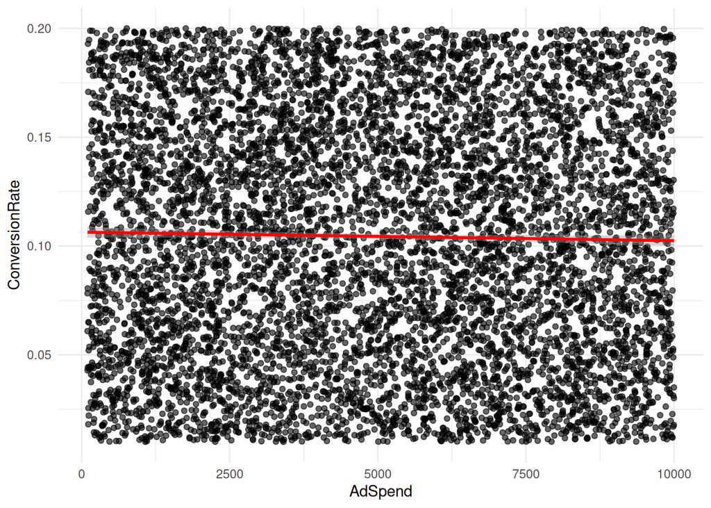

```r
ggplot(df, aes(x = AdSpend, y = ConversionRate)) +
  geom_point(alpha = 0.6) +
  geom_smooth(method = "lm", color = "red") +
  theme_minimal()
```

**Comentário:** Mostra como o investimento influencia a taxa de conversão, indicando possíveis retornos crescentes ou decrescentes. Mesmo com aumento no investimento (AdSpend), a taxa de conversão se mantém praticamente constante, indicando que o investimento isolado não explica a variação na conversão.

## 📈 Relação CTR × ConversionRate

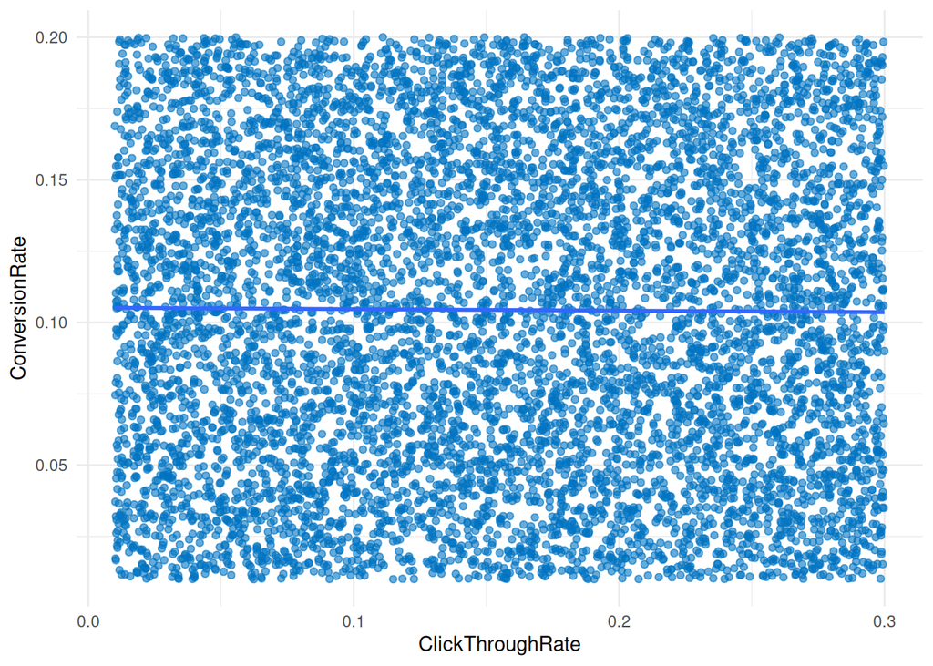

```r
ggplot(df, aes(x = ClickThroughRate, y = ConversionRate)) +
  geom_point(alpha = 0.6, color = "#0073C2FF") +
  geom_smooth(method = "lm", se = FALSE) +
  theme_minimal()
```

**Comentário:** Analisa se um maior engajamento (CTR) tende a aumentar a taxa de conversão. A ausência de tendência na linha de regressão mostra que CTR não explica a variação na taxa de conversão. Isso pode ocorrer quando os usuários clicam, mas não encontram relevância no conteúdo ou quando outros fatores (p.ex., segmentação, experiência no site) pesam mais no resultado.

# 🔍 Modelagem Preditiva — Regressão Logística

```r
model <- glm(Conversion ~ Age + Income + AdSpend + ClickThroughRate +
               TimeOnSite + EmailClicks + PreviousPurchases + LoyaltyPoints,
             data = df, family = binomial)

summary(model)
```

```
##
## Call:
## glm(formula = Conversion ~ Age + Income + AdSpend + ClickThroughRate +
##     TimeOnSite + EmailClicks + PreviousPurchases + LoyaltyPoints,
##     family = binomial, data = df)
##
## Coefficients:
##                     Estimate Std. Error z value Pr(>|z|)
## (Intercept)       -2.051e+00  2.004e-01 -10.236   <2e-16 ***
## Age                4.267e-04  2.399e-03   0.178    0.859
## Income             8.874e-07  9.543e-07   0.930    0.352
## AdSpend            1.520e-04  1.316e-05  11.550   <2e-16 ***
## ClickThroughRate   5.067e+00  4.428e-01  11.443   <2e-16 ***
## TimeOnSite         1.084e-01  8.851e-03  12.251   <2e-16 ***
## EmailClicks        1.604e-01  1.318e-02  12.169   <2e-16 ***
## PreviousPurchases  1.306e-01  1.273e-02  10.259   <2e-16 ***
## LoyaltyPoints      2.339e-04  2.567e-05   9.110   <2e-16 ***
## ---
## Signif. codes:  0 '***' 0.001 '**' 0.01 '*' 0.05 '.' 0.1 ' ' 1
##
## (Dispersion parameter for binomial family taken to be 1)
##
##     Null deviance: 5981.5  on 7999  degrees of freedom
## Residual deviance: 5245.5  on 7991  degrees of freedom
## AIC: 5263.5
##
## Number of Fisher Scoring iterations: 5
```

**Comentário:** A regressão identifica quais variáveis têm maior impacto na probabilidade de conversão. O modelo revela que a conversão é principalmente influenciada por fatores comportamentais e de engajamento, enquanto características demográficas não exercem efeito relevante. As variáveis AdSpend, ClickThroughRate, TimeOnSite, EmailClicks, PreviousPurchases e LoyaltyPoints apresentam efeitos positivos e altamente significativos, indicando que ações que estimulam engajamento e fidelização têm maior impacto na performance de conversão. O ajuste do modelo é satisfatório, mostrando melhoria substancial em relação ao modelo nulo.

## 📏 Avaliação do Modelo — ROC e AUC

```r
df$pred <- predict(model, type = "response")

roc_obj <- roc(df$Conversion, df$pred)
```

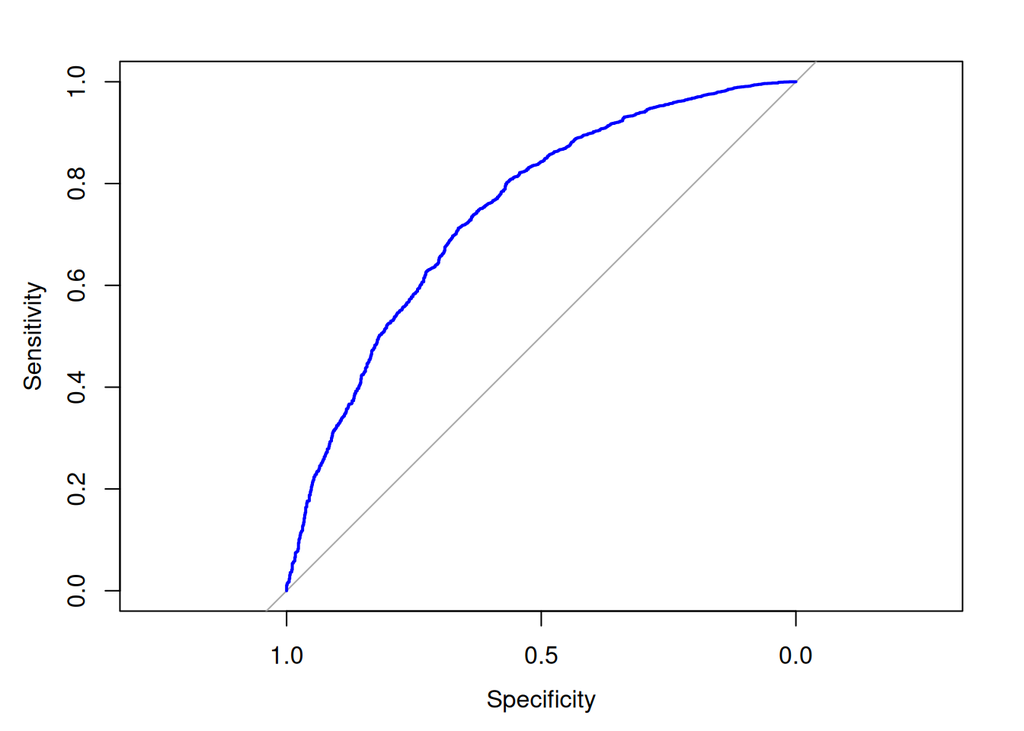

```r
plot(roc_obj, col = "blue")
```

```r
auc(roc_obj)
```

```
## Area under the curve: 0.7448
```

**Comentário:** A curva ROC e o AUC medem o quão bem o modelo diferencia conversões de não conversões. A curva ROC evidencia que o modelo possui boa capacidade de classificação, já que a linha azul se afasta da diagonal aleatória. O AUC indica desempenho satisfatório na distinção entre usuários que convertem e os que não convertem.